# Regression

2023-11-17

Notions Connexes : Méthode des Moindres Carrés - Prédiction

- [Régression linéaire — Wikipédia](https://fr.wikipedia.org/wiki/R%C3%A9gression_lin%C3%A9aire)
- [Théorème de Gauss-Markov — Wikipédia](https://fr.wikipedia.org/wiki/Th%C3%A9or%C3%A8me_de_Gauss-Markov)

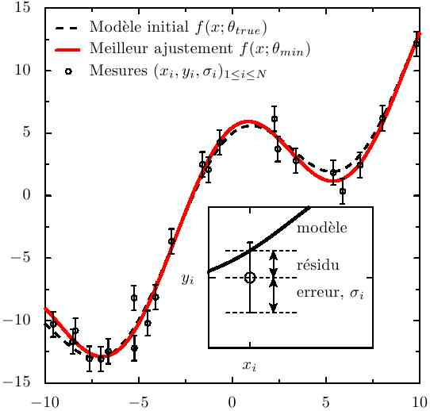

Regression Wiki

# 1 Regression Linaire - Les Bases

Etre capable de faire ses calculs à la main :

1. Calculer les Variances et Covariance non biaisée
2. Calculer le Coefficient de Corrélation (r et r²)
3. Calculer le Coefficient de Régression (a)
4. Calculer l’ordonnée à l’origine (b)

### 1.1.1 SCE

### 1.1.2 Variance non Biaisée

### 1.1.3 Covariance

### 1.1.4 Coefficient de Corrélation

### 1.1.5 Coefficient de Régression

### 1.1.6 Ordonnée à l’Origine

# 2 Régression Linéaire simple avec JAD

Exemple des Notes étudiants en fonction des heures de Travail * [Régression linéaire simple - YouTube](https://www.youtube.com/watch?v=MZyCKNFrn2E&list=PLw8egrepAHVrUiK0pKCLTPUKeR73prLZN&index=6) * Méthode de Moindre Carré (A Vérifier)  
* Variance, Covariance  
* Prédiction

# 3 Révisions Niveau Terminale

## 3.1 => Pour commencer Aller voir les exemples x1 =>

- [La droite de régression : la méthode des moindres carrés - myMaxicours](https://www.maxicours.com/se/cours/la-droite-de-regression-la-methode-des-moindres-carres/) * droite dite « de régression de y en x »  
  Exemple 1 : De base à Maîtriser
- Calcul à la Main et avec R
- Changement de Variable et fontion exponentielle (Bonus)

Obtenir le Modèle Linéaire avec R et Calculer X et Y

```r
# Exemple de données
y <- c(1, 2, 3, 4, 5)
x <- c(2, 3, 5, 4, 6)

# Ajustement du modèle linéaire
modele_lineaire <- lm(y ~ x)

# Obtention des coefficients du modèle, y = a + b*x
coefficients <- coef(modele_lineaire)

# Pente (coefficient associé à la variable x)
pente <- coefficients[2]

# Affichage de la pente
cat("La pente de la droite de régression est :", pente, "\n")
```

```
## La pente de la droite de régression est : 0.9
```

```r
# Ordonnée à l'origine (coefficient associé à la constante)
ordonnee_origine <- coefficients[1]

# Affichage de l'ordonnée à l'origine (Intercept)
cat("L'ordonnée à l'origine de la droite de régression est :", ordonnee_origine, "\n")
```

```
## L'ordonnée à l'origine de la droite de régression est : -0.6
```

```
* Calculer les coordonnées d’un point moyen ?
* Cette droite réalise un **ajustement affine** du nuage de points (Se référer à la fiche « Point moyen et droite d’ajustement » pour plus de précisions.)

* Changement de Variable (cf fonctions polynôme, exponentielle et logarithme.)
```

# 4 Cours Complets

- [Régression Linéaire. Méthode des Moindres Carrés (1h) (Saïd Chermak - infomaths.com) YT](https://www.youtube.com/watch?v=RQYnlgkgsUA)
- [Analyse de variance à 1 facteur - YouTube (Jérome PAGES - MathAgroCampus)](https://www.youtube.com/watch?v=M70yMVlQbUs) keywords : Modèles, Estimation de Paramètres, Résidus (Ecarts au Modèle), Décomposition de la variabilité (analyse de variance), test global de l’effet facteur,

KHAN Academy

- [Statistiques | 5e année secondaire - 4 h | Mathématiques | Khan Academy](https://fr.khanacademy.org/math/be-5eme-secondaire4h2/xe8f0cb2c937e9fc1:statistiques) (, Covariance, Correlation, Regression, Introduction aux Résidus, )
- [Introduction à la droite d’ajustement (vidéo) | Khan Academy (5e année secondaire - 2 h)](https://fr.khanacademy.org/math/be-5eme-secondaire2h2/x741278364a599ec1:untitled-593/x741278364a599ec1:ajustement-lineaire-droite-de-regression/v/fitting-a-line-to-data)
- [Droite de régression et méthode des moindres carrés (vidéo) | Khan Academy (5e année secondaire - 4 h)](https://fr.khanacademy.org/math/be-5eme-secondaire4h2/xe8f0cb2c937e9fc1:statistiques/xe8f0cb2c937e9fc1:determiner-l-equation-de-la-droite-des-moindres-carres/v/squared-error-of-regression-line)
- [Statistique et probabilités - Niveau 1 | Mathématiques | Khan Academy](https://fr.khanacademy.org/math/statistics-probability)  
  16 Chapitres / 134 Compétences  
  Keywords : Modélisation (4), Etude Bivariée (5), IC(11), Tests (12,13,14)(Chi2), Régression NON linéaire (15), ANOVA(16)
- [Statistique et probabilités - Niveau 2 | Mathématiques | Khan Academy](https://fr.khanacademy.org/math/probability)
- [Introduction à la biologie (vidéo) | Khan Academy](https://fr.khanacademy.org/science/high-school-biology/hs-biology-foundations/hs-biology-and-the-scientific-method/v/overview-of-biology)
- [Chapitre 4 : Régression linéaire (pdf) (fermin.perso.math.cnrs.fr)](https://fermin.perso.math.cnrs.fr/Files/Chap3.pdf)  
  Tres complet https://fermin.perso.math.cnrs.fr/ Ana Karina Fermin Rodriguez - Maître de conférence - Université Paris Ouest Nanterre La Défense(https://fermin.perso.math.cnrs.fr/) UFR SPSE-Master 1 PMP STA 21 Méthodes statistiques pour l’analyse des données en psychologie [Enseignements : L3 Stat => M2 DS](https://fermin.perso.math.cnrs.fr/enseignement.html)

$\Leftarrow$ $\Uparrow$ Sommaire